# NHL Shots per Goal Model

Sasank Vishnubhatla

In the NHL, goalies are arguably one of the most teammembers. Most deep postseason runs rely on consistent goalie play. However, being able to compare goalies tends to be difficult, since consistency is extremely hard for a goalie. Few goalies have been consistent their entire career. Of the modern day goalies, very few exemplify extreme consistency: Henrik Lundqvist, Marc-Andre Fleury, Roberto Luongo and Jonathan Quick to name a few.

In this document, I’ll be detailing an analysis and seeing how it pertains to consistency. The data used has been taken from MoneyPuck.

# Data Formatting

So, let’s load in our data:

```r
data_2017 = read.csv("data/2017.csv")
```

We’ll be starting with the 2017-2018 season. Since we have an extremely large amount of data, we need to clean it up. We’ll only be looking at regular season games, initially, so we can start by subsetting our data on that.

```r
regular_season = subset(data_2017, isPlayoffGame == 0)
```

Some important columns we need to keep are:

- xCord
- yCord
- xCordAdjusted
- yCordAdjusted
- shotAngle
- shotAngleAdjusted
- shotDistance
- playerPositionThatDidEvent
- goalieIdForShot
- goalieNameForShot
- shooterPlayerId
- shooterName
- game_id

We’ll rename some of the columns, so here is a handy table of the old column names and the new column names.

| Old Column Name | New Column Name |
| --- | --- |
| xCord | x |
| yCord | y |
| xCordAdjusted | x_adj |
| yCordAdjusted | y_adj |
| shotAngle | angle |
| shotAngleAdjusted | angle_adj |
| goal | goal |
| goalieIdForShot | goalie_id |
| goalieNameForShot | goalie_name |
| shooterPlayerId | skater_id |
| shooterName | skater_name |
| playerPositionThatDidEvent | pos |
| game_id | game |

Now, let’s create a new dataframe with just those columns.

```r
analysis = data.frame(x = regular_season$xCord,
                      y = regular_season$yCord,
                      x_adj = regular_season$xCordAdjusted,
                      y_adj = regular_season$yCordAdjusted,
                      angle = regular_season$shotAngle,
                      angle_adj = regular_season$shotAngleAdjusted,
                      goal = regular_season$goal,
                      goalie_id = regular_season$goalieIdForShot,
                      goalie_name = regular_season$goalieNameForShot,
                      skater_id = regular_season$shooterPlayerId,
                      skater_name = regular_season$shooterName,
                      pos = regular_season$playerPositionThatDidEvent,
                      game = regular_season$game_id)
```

With this `analysis` dataframe, we can start looking at a proposed statistic: shots per goal.

# Shots Per Goal

Shots per goal is a new statistic. Initially, when I had this idea, it was only for goalies. [This article](http://sasankvishnubhatla.net/nhl-goalie-shot-analysis/) details an initial attempt at analyzing what a shot per goal means. In that initial analysis, I looked at several goalies and tried to determine if there was any significance in what a shot per goal meant. However, now, with further thought, we’ll be looking at what a shot per goal means to more than just goalies.

## Goalie Aspect

Let’s start be looking at a few select goalies from the 2017-2018 season:

1. Braden Holtby
2. Marc-Andre Fleury
3. Connor Hellebuyck
4. Carey Price
5. Andrei Vasilevskiy
6. Robin Lehner
7. Antti Niemi
8. Jaroslav Halak
9. Peter Budaj
10. Jacob Markstrom

To start, we need a function that will take a goalie’s name and return all their data. So, let’s write our specified subset function:

```r
get_goalie_data <- function(data, name) {
    subset(data, goalie_name == name)
}
```

So, let’s now start with Brayden Holtby:

```r
holtby = get_goalie_data(analysis, "Braden Holtby")
```

### Shots per Goals for a Season

With this data, we can now calculate a few shot per goal stats. Let’s start with the most basic: shots per goal for the entire season.

```r
calculate_spg = function(data) {
    total_shots = length(data$goal)
    temp = subset(data, goal == 1)
    total_goals = length(temp$goal)
    if (total_goals == 0) {
        100
    } else {
        total_shots / total_goals
    }
}
```

Note that if a goalie has a shutout, the SPG will be 100. This is due to R using Inf and not throwing an error.

Now with this function, let’s calculate the total shots per goal for the 2017-2018 season for Braden Holtby.

```r
holtby_spg_season = calculate_spg(holtby)
```

We see that Holtby gives up one goal per 15.339869281 shots. We can calculate the season shots per goal for each goaltender now.

```r
fleury = get_goalie_data(analysis, "Marc-Andre Fleury")
fleury_spg_season = calculate_spg(fleury)

hellebuyck = get_goalie_data(analysis, "Connor Hellebuyck")
hellebuyck_spg_season = calculate_spg(hellebuyck)

price = get_goalie_data(analysis, "Carey Price")
price_spg_season = calculate_spg(price)

vasilevskiy = get_goalie_data(analysis, "Andrei Vasilevskiy")
vasilevskiy_spg_season = calculate_spg(vasilevskiy)

lehner = get_goalie_data(analysis, "Robin Lehner")
lehner_spg_season = calculate_spg(lehner)

niemi = get_goalie_data(analysis, "Antti Niemi")
niemi_spg_season = calculate_spg(niemi)

halak = get_goalie_data(analysis, "Jaroslav Halak")
halak_spg_season = calculate_spg(halak)

budaj = get_goalie_data(analysis, "Peter Budaj")
budaj_spg_season = calculate_spg(budaj)

markstrom = get_goalie_data(analysis, "Jacob Markstrom")
markstrom_spg_season = calculate_spg(markstrom)
```

Let’s take a look at what the results are:

| Goalie | Shots per Goal |
| --- | --- |
| Fleury | 19.08 |
| Hellebuyck | 18.3076923077 |
| Price | 13.4864864865 |
| Vasilevskiy | 16.656626506 |
| Lehner | 14.8661971831 |
| Niemi | 15.9523809524 |
| Halak | 14.65625 |
| Budaj | 10.7777777778 |
| Markstrom | 15.9868421053 |

With each of these shots per goal calculations, we can begin to delve deeper into what a shot per goal (SPG) means for a goalie.

#### A Mathematical Aside

Ideally, during a hockey game, a goalie would like to have a shutout. A shutout, the best goalie performance possible, would equate to an infinite SPG Now, let’s continue this hypothetical exercise. Let us say that our goalie faces a total of 30 shots per game, a figure that now seems quite average in the NHL. With a shutout, the SPG is infinite. With one goal allowed, the SPG will drop down to 30. With another goal allowed, the spg drops to 15. Here is a table which depicts the decay of SPG as goals are allowed for a theoretical 30 shot game:

| Goals Allowed | Shots per Goal (30 shots) |
| --- | --- |
| 0 | infinite |
| 1 | 30 |
| 2 | 15 |
| 3 | 10 |
| 4 | 7.5 |
| 5 | 6 |
| 6 | 5 |

If one were to plot this trend, it would look like this:

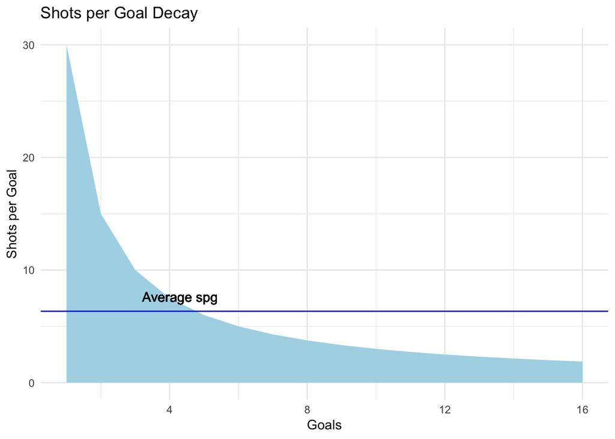

Mathematically speaking, we are able to formulaically determine the equation of this curve. We see that this curve is:

$$spg(shots = 30, goals) = \frac{shots}{goals} = \frac{30}{goals}$$

Therefore, whenever we take the limit to determine the lower bound of this function, we see that the lowest possible SPG is:

$$\lim_{goals \to \infty} spg(shots = 30, goals) = \lim_{goals \to \inf} \frac{30}{goals} = 0$$

Therefore, we now know that the lowest possible SPG is 0.

### Understanding Shots Per Goal

In the NHL, a goalie (and a team ideally) strives to lower his goals against average (GAA). However, given the nature of GAA, it can be misleading. Similar to a pitchers ERA, GAA is a general stat. It does not give insight into his performance.

For example, a goalie could have a GAA of 3.0 on a given night, but saved 45 or 48 shots. A GAA of 3.0 is considered not very good in the current NHL, but the goalie played exceptionally well given that he had a 93.75% save percentage. Whenever GAA is paired with save percentage, we are given a better picture. However, this picture is still slightly misleading.

Now, let’s look at the other extreme; a goalie has a GAA of 1.0 for a game, but only faced 20 shots. With this, we are looking at a GAA of 1.0 and a save percentage of 90.00%. The GAA says the goalie is elite, but the save percentage says the goalie is a benchwarmer. Pairing GAA and save percentage will only take an analysis so far, but there is more to look at.

If we add SPG into the picture, we might be able to gain more insight into the goalie’s performance. Let’s revist our goalie with a 3.00 GAA and 93.75% save percentage. Since he faced a 48 shots and gave up 3 goals, he has a SPG of 16.0. Our goalie on average will save 16 shots before letting up a goal. On a good day, that means a period or two of shutout hockey. On a bad day, they let up a goal per period.

| Goalie | GAA | Save Percentage | Shots Per Goal | Shots Faced |
| --- | --- | --- | --- | --- |
| A | 3.00 | 93.75% | 16.0 | 48 |
| B | 1.00 | 90.00% | 10.0 | 20 |

From here, we can determine which goalie is better. Categorically, goalie A wins as he has a better save percentage and SPG. Though goalie B has a better GAA, we know through SPG and save percentage, that goalie B will give up more goals given a higher shot volume.

### Drawbacks of Shots per Goal

An immediate drawback of SPG is that is does not take the defense into account. However, both GAA and save percentage, also have this drawback. Taking defense out of the picture in a statistic may be not as useful as assessing the goalie by himself takes a large chunk of a team out of the statistic. Both GAA and save percentage reflect on the defensive play of team since a goalie can only do so much. A perfect example of this is Cam Talbot in 2016-2017. Cam Talbot started **73** games for the Edmonton Oilers and put up a 2.39 GAA and 91.9% save percentage (numbers taken from Hockey Reference). These numbers are not spectacular, but it does reflect on the team’s defense: it was terrible. His SPG that season was 12.38. This SPG additionally reflects on his team’s defensive play.

Additionally, SPG does not account for shot attempts, only shots on goal. There is a significant difference between the two, as a defense can be excellent at shot blocking. However, their goalie may not be as good, so the defense is forced to block shots more. This may lead to a slightly inflated SPG. In the future, more research can be done on this, leading to a new statistic: shot attempts per goal (SaPG). Currently, I do not have the data to calculate this. However, I do suspect that SaPG can be used not only as a metric to determine the effectiveness of a goalie, but also determine how good a defense is.

### Determining Shots Per Goal for a Single Game

In our goalie data, we have a column called `game`. This column tells us what game we are looking at. So, we can subset on a specific game and determine the shots per goal that game. Let’s write a few functions to help us do that.

```r
get_games = function(data) {
    unique(data$game)
}

get_game_data = function(data, game_id) {
    subset(data, game == game_id)
}
```

With the use of some functional programming, we can create a list of dataframes for each game.

```r
get_all_games = function(data) {
    games = get_games(data)
    Map(function(x) get_game_data(data, x), games)
}
```

Note that `get_all_games` doesn’t return a vector, but a large list.

Now, with our `calculate_spg` function, we can get the SPG for each game. Here’s a function that does that:

```r
get_spg_games = function(data) {
    gameframes = get_all_games(data)
    gamespg = map(gameframes, function(x) calculate_spg(x))
    unlist(gamespg, use.names = FALSE)
}
```

Please note that the `map` function used here comes from the `purrr` library.

With `get_spg_games`, we can start looking at trends in performances. Let’s start by first calculating SPG for each game for each of our select goalies.

```r
holtby_spg_games = get_spg_games(holtby)
fleury_spg_games = get_spg_games(fleury)
hellebuyck_spg_games = get_spg_games(hellebuyck)
price_spg_games = get_spg_games(price)
vasilevskiy_spg_games = get_spg_games(vasilevskiy)
lehner_spg_games = get_spg_games(lehner)
niemi_spg_games = get_spg_games(niemi)
halak_spg_games = get_spg_games(halak)
budaj_spg_games = get_spg_games(budaj)
markstrom_spg_games = get_spg_games(markstrom)
```

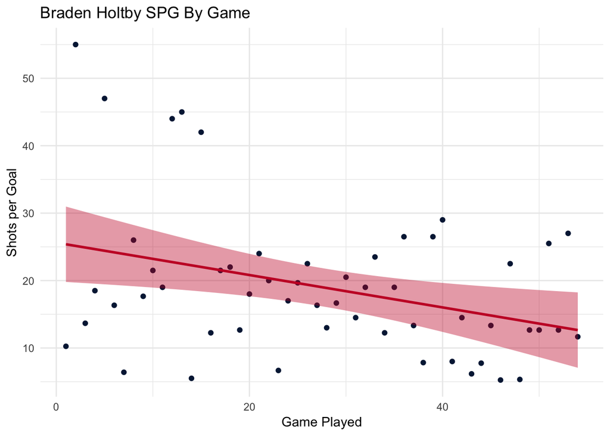

In this graph, we see that each point is Holtby’s SPG for a specific game. The line is a linear model which shows that over the season, Holtby seemed to follow a decreasing linear trend.

Let’s now look at someone who he faced in the Stanley Cup finals: Marc-Andre Fleury

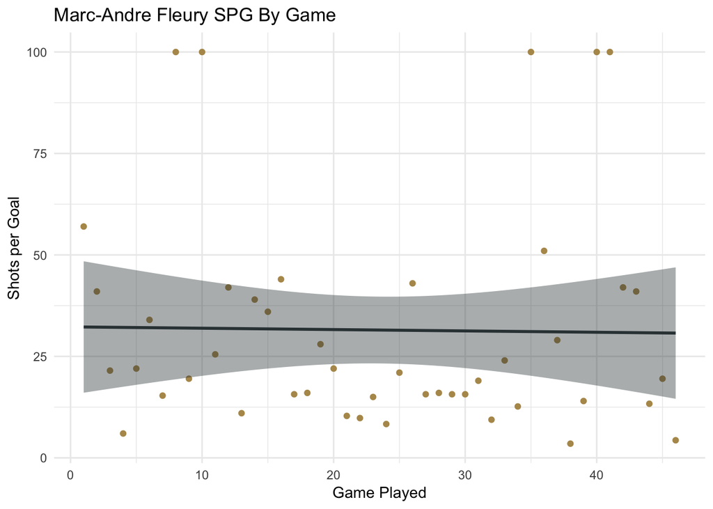

A final player I’d like to look at is Carey Price. Price is supposed to be a Vezina caliber goaltender every year. However, injuries have set him back. Let’s see how his trend is for the 2017-2018 season.

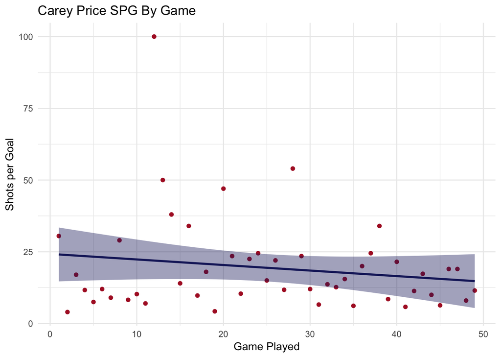

```r
plot = plot_spg_game(price_spg_games,
                     "#AF1E2D",
                     "#192168",
                     "Carey Price")
plot
```

Similar to Holtby, Price has a decreasing trend in his SPG. However, Price’s decreasing trend is less than Holtby’s.

### Shots per Goal from Specific Locations